# vehicle_detection_project_fn

**Problem statement 1:**

Autonomous vehicles (AV) and intelligent transport systems (ITS) are the future of road transport. Automatic detection of vehicles on the road in real-time helps AV technology and makes ITS more intelligent in terms of vehicle tracking, vehicle counting, and road incident response.

**Objective part 1:**

As the first part of this project, you need to develop an AI model using a deep learning framework that predicts the type of vehicle present in an image as well as localizes the vehicle by rectangular bounding box.

```python
#Import the packages
from ultralytics import YOLO
import pandas as pd
import os
import shutil
from PIL import Image
```

**Object detection**

1. Create a parent folder for custom model training and child folders to store data
2. Prepare the dataset for model training and keep the following points in mind while preparing it • This dataset contains many images, and depending on the compute power of the VM, it might take a very long time to unzip this huge amount of data

```python
# Define paths
from ultralytics import YOLO
import pandas as pd
import os
import shutil
from PIL import Image



csv_path = "./sample_data/Part1/labels.csv"
img_folder = "./sample_data/Part1/images/"
yolo_dataset_path = "./sample_data/yolo_dataset/"
yolo_images_dir = os.path.join(yolo_dataset_path, "images")
yolo_labels_dir = os.path.join(yolo_dataset_path, "labels")

# Create necessary folders
for split in ['train', 'val']:
    os.makedirs(os.path.join(yolo_images_dir, split), exist_ok=True)
    os.makedirs(os.path.join(yolo_labels_dir, split), exist_ok=True)

# Load CSV
df = pd.read_csv(csv_path, header=None)
df.columns = ['image_id', 'class_name', 'x_min', 'y_min', 'x_max', 'y_max']

# Class name to ID mapping
class_map = {name: idx for idx, name in enumerate(df['class_name'].unique())}

# Group by image
grouped = df.groupby('image_id')
print(grouped.head())
# Simple train/val split
image_ids = df['image_id'].unique()
threshold = 5657
filtered_img = [s for s in image_ids if int(s) <= threshold]
split_idx = int(len(filtered_img) * 0.8)
train_ids = set(filtered_img[:split_idx])

for image_id, group in grouped:
    file_name = f"{str(image_id).zfill(8)}.jpg"
    orig_path = os.path.join(img_folder, file_name)

    if not os.path.exists(orig_path):
        continue  # skip if image is missing

    # Determine split
    split = 'train' if image_id in train_ids else 'val'

    # Copy image
    dst_img_path = os.path.join(yolo_images_dir, split, file_name)
    shutil.copy(orig_path, dst_img_path)

    # Get image size
    with Image.open(orig_path) as img:
        width, height = img.size

    # Convert annotations
    yolo_lines = []
    for _, row in group.iterrows():
        class_id = class_map[row['class_name']]
        x_center = (row['x_min'] + row['x_max']) / 2 / width
        y_center = (row['y_min'] + row['y_max']) / 2 / height
        bbox_width = (row['x_max'] - row['x_min']) / width
        bbox_height = (row['y_max'] - row['y_min']) / height
        yolo_lines.append(f"{class_id} {x_center} {y_center} {bbox_width} {bbox_height}")

    # Save label file
    label_path = os.path.join(yolo_labels_dir, split, file_name.replace(".jpg", ".txt"))
    with open(label_path, "w") as f:
        f.write("\n".join(yolo_lines))
```

```
        image_id             class_name  x_min  y_min  x_max  y_max
0              0           pickup_truck    213     34    255     50
1              0                    car    194     78    273    122
2              0                    car    155     27    183     35
3              0      articulated_truck     43     25    109     55
4              0                    car    106     32    124     45
...          ...                    ...    ...    ...    ...    ...
351544    110590                    car     18     57     97     98
351545    110591      articulated_truck      2     71    690    351
351546    110592           pickup_truck      3    240    214    378
351547    110592                    car    465    111    507    135
351548    110592  non-motorized_vehicle    197    187    318    269

[293274 rows x 6 columns]
```

```python
from glob import glob
print("Train images:", len(glob(os.path.join(yolo_images_dir, 'train', '*.jpg'))))
print("Val images:", len(glob(os.path.join(yolo_images_dir, 'val', '*.jpg'))))
```

```
Train images: 4500
Val images: 1126
```

```python
#create the yolo config file
yolo_dataset_path = "./sample_data/yolo_dataset/"
yaml_path = "./sample_data/yolo_dataset/data.yaml"
with open(yaml_path, "w") as f:
    f.write(f"""
path: {yolo_dataset_path}
train: images/train
val: images/val

nc: {len(class_map)}
names: {list(class_map.keys())}
""")
```

3. Create an CNN architecture for object detection of your choice to train an object detection model. Please note that algorithm or architecture selection is a very important aspect of ML model training, and you must pick the one that works the best for your dataset

```python
model = YOLO("yolov8n.pt")  # Use yolov8n for speed, or yolov8s/m/l/x for accuracy
results = model.train(data=yaml_path, epochs=20, imgsz=640)
```

```
Ultralytics 8.3.141 🚀 Python-3.11.12 torch-2.6.0+cu124 CUDA:0 (Tesla T4, 15095MiB)
engine/trainer: agnostic_nms=False, amp=True, augment=False, auto_augment=randaugment, batch=16, bgr=0.0, box=7.5, cache=False, cfg=None, classes=None, close_mosaic=10, cls=0.5, conf=None, copy_paste=0.0, copy_paste_mode=flip, cos_lr=False, cutmix=0.0, data=./sample_data/yolo_dataset/data.yaml, degr…
Overriding model.yaml nc=80 with nc=11

                   from  n    params  module                                       arguments
  0                  -1  1       464  ultralytics.nn.modules.conv.Conv             [3, 16, 3, 2]
  1                  -1  1      4672  ultralytics.nn.modules.conv.Conv             [16, 32, 3, 2]
  2                  -1  1      7360  ultralytics.nn.modules.block.C2f             [32, 32, 1, True]
  3                  -1  1     18560  ultralytics.nn.modules.conv.Conv             [32, 64, 3, 2]
  4                  -1  2     49664  ultralytics.nn.modules.block.C2f             [64, 64, 2, True]
  5                  -1  1     73984  ultralytics.nn.modules.conv.Conv             [64, 128, 3, 2]
  6                  -1  2    197632  ultralytics.nn.modules.block.C2f             [128, 128, 2, True]
  7                  -1  1    295424  ultralytics.nn.modules.conv.Conv             [128, 256, 3, 2]
  8                  -1  1    460288  ultralytics.nn.modules.block.C2f             [256, 256, 1, True]
  9                  -1  1    164608  ultralytics.nn.modules.block.SPPF            [256, 256, 5]
 10                  -1  1         0  torch.nn.modules.upsampling.Upsample         [None, 2, 'nearest']
 11             [-1, 6]  1         0  ultralytics.nn.modules.conv.Concat           [1]
 12                  -1  1    148224  ultralytics.nn.modules.block.C2f             [384, 128, 1]
 13                  -1  1         0  torch.nn.modules.upsampling.Upsample         [None, 2, 'nearest']
 14             [-1, 4]  1         0  ultralytics.nn.modules.conv.Concat           [1]
 15                  -1  1     37248  ultralytics.nn.modules.block.C2f             [192, 64, 1]
 16                  -1  1     36992  ultralytics.nn.modules.conv.Conv             [64, 64, 3, 2]
 17            [-1, 12]  1         0  ultralytics.nn.modules.conv.Concat           [1]
 18                  -1  1    123648  ultralytics.nn.modules.block.C2f             [192, 128, 1]
 19                  -1  1    147712  ultralytics.nn.modules.conv.Conv             [128, 128, 3, 2]
 20             [-1, 9]  1         0  ultralytics.nn.modules.conv.Concat           [1]
 21                  -1  1    493056  ultralytics.nn.modules.block.C2f             [384, 256, 1]
 22        [15, 18, 21]  1    753457  ultralytics.nn.modules.head.Detect           [11, [64, 128, 256]]
Model summary: 129 layers, 3,012,993 parameters, 3,012,977 gradients, 8.2 GFLOPs

Transferred 319/355 items from pretrained weights
Freezing layer 'model.22.dfl.conv.weight'
AMP: running Automatic Mixed Precision (AMP) checks...
AMP: checks passed ✅
train: Fast image access ✅ (ping: 0.0±0.0 ms, read: 815.5±333.6 MB/s, size: 24.9 KB)
```

```
train: Scanning /content/sample_data/yolo_dataset/labels/train.cache... 4500 images, 0 backgrounds, 0 corrupt: 100%|██████████| 4500/4500 [00:00<?, ?it/s]
```

```
albumentations: Blur(p=0.01, blur_limit=(3, 7)), MedianBlur(p=0.01, blur_limit=(3, 7)), ToGray(p=0.01, method='weighted_average', num_output_channels=3), CLAHE(p=0.01, clip_limit=(1.0, 4.0), tile_grid_size=(8, 8))
val: Fast image access ✅ (ping: 0.0±0.0 ms, read: 634.1±367.1 MB/s, size: 23.5 KB)
```

```
val: Scanning /content/sample_data/yolo_dataset/labels/val.cache... 1126 images, 0 backgrounds, 0 corrupt: 100%|██████████| 1126/1126 [00:00<?, ?it/s]
```

```
Plotting labels to runs/detect/train2/labels.jpg...
optimizer: 'optimizer=auto' found, ignoring 'lr0=0.01' and 'momentum=0.937' and determining best 'optimizer', 'lr0' and 'momentum' automatically...
optimizer: AdamW(lr=0.000667, momentum=0.9) with parameter groups 57 weight(decay=0.0), 64 weight(decay=0.0005), 63 bias(decay=0.0)
Image sizes 640 train, 640 val
Using 2 dataloader workers
Logging results to runs/detect/train2
Starting training for 20 epochs...

      Epoch    GPU_mem   box_loss   cls_loss   dfl_loss  Instances       Size
```

```
       1/20      2.16G      1.231      2.372       1.08         14        640: 100%|██████████| 282/282 [01:22<00:00,  3.43it/s]
                 Class     Images  Instances      Box(P          R      mAP50  mAP50-95): 100%|██████████| 36/36 [00:11<00:00,  3.27it/s]
```

```
                   all       1126       3806      0.451      0.228      0.215      0.155

      Epoch    GPU_mem   box_loss   cls_loss   dfl_loss  Instances       Size
```

```
       2/20       2.3G       1.16      1.595      1.044         23        640: 100%|██████████| 282/282 [01:33<00:00,  3.00it/s]
                 Class     Images  Instances      Box(P          R      mAP50  mAP50-95): 100%|██████████| 36/36 [00:09<00:00,  3.98it/s]
```

```
                   all       1126       3806      0.394      0.302      0.285      0.194

      Epoch    GPU_mem   box_loss   cls_loss   dfl_loss  Instances       Size
```

```
       3/20       2.3G       1.14      1.403       1.04         25        640: 100%|██████████| 282/282 [01:18<00:00,  3.58it/s]
                 Class     Images  Instances      Box(P          R      mAP50  mAP50-95): 100%|██████████| 36/36 [00:08<00:00,  4.02it/s]
```

```
                   all       1126       3806      0.462      0.365      0.343      0.232

      Epoch    GPU_mem   box_loss   cls_loss   dfl_loss  Instances       Size
```

```
       4/20       2.3G      1.115      1.259      1.032         22        640: 100%|██████████| 282/282 [01:17<00:00,  3.62it/s]
                 Class     Images  Instances      Box(P          R      mAP50  mAP50-95): 100%|██████████| 36/36 [00:08<00:00,  4.32it/s]
```

```
                   all       1126       3806      0.541      0.417      0.419      0.291

      Epoch    GPU_mem   box_loss   cls_loss   dfl_loss  Instances       Size
```

```
       5/20       2.3G       1.08      1.151      1.019         16        640: 100%|██████████| 282/282 [01:18<00:00,  3.60it/s]
                 Class     Images  Instances      Box(P          R      mAP50  mAP50-95): 100%|██████████| 36/36 [00:09<00:00,  3.89it/s]
```

```
                   all       1126       3806      0.439      0.437       0.41      0.279
```

```
      Epoch    GPU_mem   box_loss   cls_loss   dfl_loss  Instances       Size
```

```
       6/20       2.3G      1.068      1.086      1.013         20        640: 100%|██████████| 282/282 [01:16<00:00,  3.69it/s]
                 Class     Images  Instances      Box(P          R      mAP50  mAP50-95): 100%|██████████| 36/36 [00:09<00:00,  3.80it/s]
```

```
                   all       1126       3806      0.418      0.526      0.452      0.319

      Epoch    GPU_mem   box_loss   cls_loss   dfl_loss  Instances       Size
```

```
       7/20      2.31G      1.037      1.018      1.003         28        640: 100%|██████████| 282/282 [01:15<00:00,  3.73it/s]
                 Class     Images  Instances      Box(P          R      mAP50  mAP50-95): 100%|██████████| 36/36 [00:08<00:00,  4.38it/s]
```

```
                   all       1126       3806       0.55      0.463      0.475      0.334

      Epoch    GPU_mem   box_loss   cls_loss   dfl_loss  Instances       Size
```

```
       8/20      2.33G       1.04     0.9863      1.004         22        640: 100%|██████████| 282/282 [01:16<00:00,  3.67it/s]
                 Class     Images  Instances      Box(P          R      mAP50  mAP50-95): 100%|██████████| 36/36 [00:08<00:00,  4.43it/s]
```

```
                   all       1126       3806      0.554      0.433       0.46      0.318

      Epoch    GPU_mem   box_loss   cls_loss   dfl_loss  Instances       Size
```

```
       9/20      2.33G      1.024     0.9512     0.9983         17        640: 100%|██████████| 282/282 [01:16<00:00,  3.69it/s]
                 Class     Images  Instances      Box(P          R      mAP50  mAP50-95): 100%|██████████| 36/36 [00:09<00:00,  3.90it/s]
```

```
                   all       1126       3806      0.478      0.538       0.51      0.357
```

```
      Epoch    GPU_mem   box_loss   cls_loss   dfl_loss  Instances       Size
```

```
      10/20      2.33G      1.014     0.9296     0.9955         26        640: 100%|██████████| 282/282 [01:16<00:00,  3.71it/s]
                 Class     Images  Instances      Box(P          R      mAP50  mAP50-95): 100%|██████████| 36/36 [00:08<00:00,  4.08it/s]
```

```
                   all       1126       3806      0.474       0.55      0.528      0.378
```

```
Closing dataloader mosaic
albumentations: Blur(p=0.01, blur_limit=(3, 7)), MedianBlur(p=0.01, blur_limit=(3, 7)), ToGray(p=0.01, method='weighted_average', num_output_channels=3), CLAHE(p=0.01, clip_limit=(1.0, 4.0), tile_grid_size=(8, 8))

      Epoch    GPU_mem   box_loss   cls_loss   dfl_loss  Instances       Size
```

```
      11/20      2.34G     0.9834     0.8624     0.9731          8        640: 100%|██████████| 282/282 [01:15<00:00,  3.74it/s]
                 Class     Images  Instances      Box(P          R      mAP50  mAP50-95): 100%|██████████| 36/36 [00:08<00:00,  4.31it/s]
```

```
                   all       1126       3806      0.571      0.517      0.554      0.392
```

```
      Epoch    GPU_mem   box_loss   cls_loss   dfl_loss  Instances       Size
```

```
      12/20      2.37G     0.9693     0.8148     0.9642         11        640: 100%|██████████| 282/282 [01:12<00:00,  3.88it/s]
                 Class     Images  Instances      Box(P          R      mAP50  mAP50-95): 100%|██████████| 36/36 [00:08<00:00,  4.05it/s]
```

```
                   all       1126       3806      0.581      0.554      0.562      0.396
```

```
      Epoch    GPU_mem   box_loss   cls_loss   dfl_loss  Instances       Size
```

```
      13/20      2.37G     0.9593     0.7927     0.9597         18        640: 100%|██████████| 282/282 [01:12<00:00,  3.92it/s]
                 Class     Images  Instances      Box(P          R      mAP50  mAP50-95): 100%|██████████| 36/36 [00:08<00:00,  4.12it/s]
```

```
                   all       1126       3806      0.507      0.582      0.544      0.389
```

```
      Epoch    GPU_mem   box_loss   cls_loss   dfl_loss  Instances       Size
```

```
      14/20      2.37G     0.9468      0.767     0.9581         10        640: 100%|██████████| 282/282 [01:12<00:00,  3.87it/s]
                 Class     Images  Instances      Box(P          R      mAP50  mAP50-95): 100%|██████████| 36/36 [00:08<00:00,  4.17it/s]
```

```
                   all       1126       3806      0.524      0.575      0.568      0.408

      Epoch    GPU_mem   box_loss   cls_loss   dfl_loss  Instances       Size
```

```
      15/20      2.37G     0.9396     0.7394     0.9553         11        640: 100%|██████████| 282/282 [01:13<00:00,  3.84it/s]
                 Class     Images  Instances      Box(P          R      mAP50  mAP50-95): 100%|██████████| 36/36 [00:09<00:00,  3.95it/s]
```

```
                   all       1126       3806      0.568      0.571      0.571      0.413
```

```
      Epoch    GPU_mem   box_loss   cls_loss   dfl_loss  Instances       Size
```

```
      16/20      2.37G     0.9285     0.7166     0.9487         13        640: 100%|██████████| 282/282 [01:12<00:00,  3.87it/s]
                 Class     Images  Instances      Box(P          R      mAP50  mAP50-95): 100%|██████████| 36/36 [00:08<00:00,  4.42it/s]
```

```
                   all       1126       3806      0.574      0.598      0.597      0.426
```

```
      Epoch    GPU_mem   box_loss   cls_loss   dfl_loss  Instances       Size
```

```
      17/20      2.37G     0.9121     0.6981      0.945          9        640: 100%|██████████| 282/282 [01:12<00:00,  3.89it/s]
                 Class     Images  Instances      Box(P          R      mAP50  mAP50-95): 100%|██████████| 36/36 [00:08<00:00,  4.02it/s]
```

```
                   all       1126       3806      0.551      0.617      0.588      0.428
```

```
      Epoch    GPU_mem   box_loss   cls_loss   dfl_loss  Instances       Size
```

```
      18/20      2.37G     0.9094     0.6752     0.9408         12        640: 100%|██████████| 282/282 [01:11<00:00,  3.93it/s]
                 Class     Images  Instances      Box(P          R      mAP50  mAP50-95): 100%|██████████| 36/36 [00:08<00:00,  4.06it/s]
```

```
                   all       1126       3806      0.618      0.581      0.601      0.441
```

```
      Epoch    GPU_mem   box_loss   cls_loss   dfl_loss  Instances       Size
```

```
      19/20      2.37G     0.8942     0.6542     0.9312          7        640: 100%|██████████| 282/282 [01:12<00:00,  3.89it/s]
                 Class     Images  Instances      Box(P          R      mAP50  mAP50-95): 100%|██████████| 36/36 [00:08<00:00,  4.50it/s]
```

```
                   all       1126       3806      0.608      0.619      0.615      0.448
```

```
      Epoch    GPU_mem   box_loss   cls_loss   dfl_loss  Instances       Size
```

```
      20/20      2.37G     0.8829     0.6359     0.9299          7        640: 100%|██████████| 282/282 [01:13<00:00,  3.85it/s]
                 Class     Images  Instances      Box(P          R      mAP50  mAP50-95): 100%|██████████| 36/36 [00:08<00:00,  4.13it/s]
```

```
                   all       1126       3806      0.625       0.59      0.616      0.452
```

```
20 epochs completed in 0.474 hours.
Optimizer stripped from runs/detect/train2/weights/last.pt, 6.2MB
Optimizer stripped from runs/detect/train2/weights/best.pt, 6.2MB

Validating runs/detect/train2/weights/best.pt...
Ultralytics 8.3.141 🚀 Python-3.11.12 torch-2.6.0+cu124 CUDA:0 (Tesla T4, 15095MiB)
Model summary (fused): 72 layers, 3,007,793 parameters, 0 gradients, 8.1 GFLOPs
```

```
                 Class     Images  Instances      Box(P          R      mAP50  mAP50-95): 100%|██████████| 36/36 [00:10<00:00,  3.49it/s]
```

```
                   all       1126       3806      0.624      0.589      0.615      0.451
          pickup_truck        311        434      0.795      0.786      0.844      0.688
                   car        944       2544      0.835      0.882      0.912      0.667
     articulated_truck         70         81      0.655      0.751      0.725      0.542
                   bus        105        121      0.931      0.897      0.938       0.83
     motorized_vehicle        232        303       0.57      0.363      0.408      0.245
              work_van         99        104      0.629      0.654      0.615        0.5
     single_unit_truck         57         60      0.558       0.55      0.518      0.357
            pedestrian         45         92      0.457      0.266      0.331      0.166
               bicycle         22         26      0.481      0.577       0.64      0.408
 non-motorized_vehicle         19         19      0.218      0.105     0.0913     0.0615
            motorcycle         20         22      0.739      0.645      0.742      0.497
Speed: 0.2ms preprocess, 1.7ms inference, 0.0ms loss, 1.8ms postprocess per image
Results saved to runs/detect/train2
```

4. Evaluate the model and check the test results

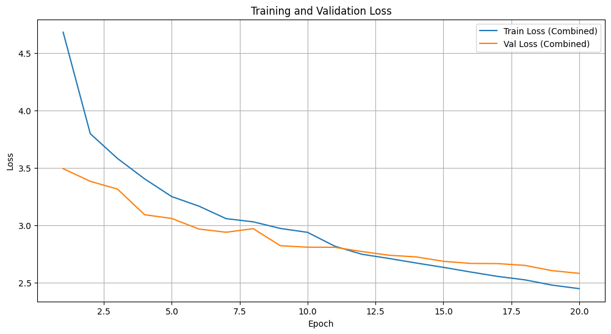

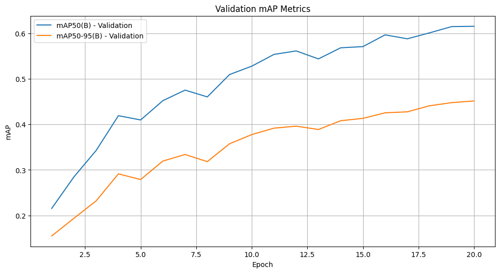

```python
import matplotlib.pyplot as plt
import pandas as pd


# Replace with the actual path to your results.csv
results_path = './runs/detect/train/results.csv'

# Read the CSV, skipping initial comments (if any)
# You might need to adjust 'skipinitialspace' or 'header' based on your file's exact format
try:
    df = pd.read_csv(results_path)
except FileNotFoundError:
    print(f"Error: {results_path} not found. Please check the path.")
    exit()

# Clean column names (YOLOv8 often has leading spaces)
df.columns = [col.strip() for col in df.columns]

# Plotting Loss
plt.figure(figsize=(12, 6))
plt.plot(df['epoch'], df['train/box_loss'] + df['train/cls_loss'] + df['train/dfl_loss'], label='Train Loss (Combined)')
plt.plot(df['epoch'], df['val/box_loss'] + df['val/cls_loss'] + df['val/dfl_loss'], label='Val Loss (Combined)')
plt.title('Training and Validation Loss')
plt.xlabel('Epoch')
plt.ylabel('Loss')
plt.legend()
plt.grid(True)
plt.show()

# Plotting mAP
plt.figure(figsize=(12, 6))
plt.plot(df['epoch'], df['metrics/mAP50(B)'], label='mAP50(B) - Validation')
plt.plot(df['epoch'], df['metrics/mAP50-95(B)'], label='mAP50-95(B) - Validation')
plt.title('Validation mAP Metrics')
plt.xlabel('Epoch')
plt.ylabel('mAP')
plt.legend()
plt.grid(True)
plt.show()
```

5. Run inferences on sample images and see if vehicles are detected accurately

```python
results_in = model.predict("./sample_data/yolo_dataset/images/val/00004523.jpg", save=True, conf=0.25)
print(results_in)

# Extract first result
r = results_in[0]

# Show class names
print("Class Names:", model.names)

# Print all predictions
for box, conf, cls_id in zip(r.boxes.xyxy, r.boxes.conf, r.boxes.cls):
    print(f"Class: {model.names[int(cls_id)]}, Confidence: {conf:.2f}, Box: {box.tolist()}")
```

[output not shown]

[output cut: 16 more lines]

```
        [  0,   0,   0],
        [  0,   0,   0],
        [  0,   0,   0]]], dtype=uint8)
orig_shape: (228, 342)
path: '/content/sample_data/yolo_dataset/images/val/00004523.jpg'
probs: None
save_dir: 'runs/detect/train22'
speed: {'preprocess': 2.9612039998028195, 'inference': 121.22001700026885, 'postprocess': 2.164272000300116}]
Class Names: {0: 'pickup_truck', 1: 'car', 2: 'articulated_truck', 3: 'bus', 4: 'motorized_vehicle', 5: 'work_van', 6: 'single_unit_truck', 7: 'pedestrian', 8: 'bicycle', 9: 'non-motorized_vehicle', 10: 'motorcycle'}
Class: work_van, Confidence: 0.80, Box: [69.21305847167969, 55.57606506347656, 138.12481689453125, 89.46800994873047]
Class: car, Confidence: 0.75, Box: [151.51165771484375, 27.57723617553711, 182.0041046142578, 35.35712432861328]
Class: car, Confidence: 0.63, Box: [69.44784545898438, 55.727657318115234, 138.2427215576172, 89.75243377685547]
Class: car, Confidence: 0.61, Box: [226.2789764404297, 27.015281677246094, 247.7737274169922, 35.183013916015625]
Class: car, Confidence: 0.58, Box: [110.9125747680664, 24.340269088745117, 129.16390991210938, 31.648591995239258]
Class: car, Confidence: 0.34, Box: [27.07554054260254, 43.211185455322266, 45.96173095703125, 55.497798919677734]
```

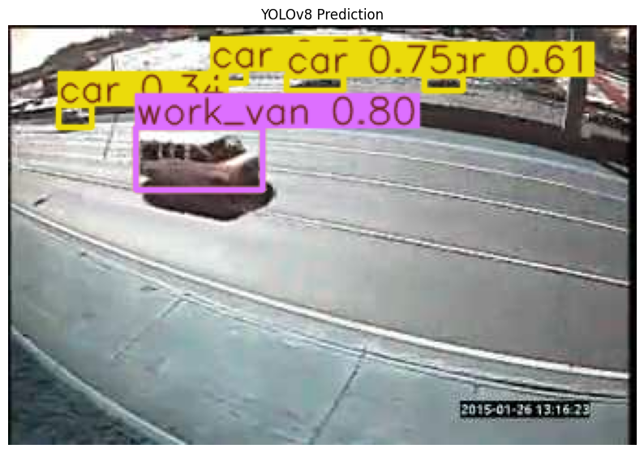

```python
# r.plot() returns an annotated image (numpy array)
annotated_img = r.plot()

# Display it with matplotlib
plt.figure(figsize=(10, 8))
plt.imshow(annotated_img)
plt.axis('off')
plt.title("YOLOv8 Prediction")
plt.show()
```

**Part 2**

**Data Science**

1. Preliminary data inspection and cleaning

   a. Perform preliminary data inspection, checking for data types, missing values, and duplicates b.Remove any columns that might not be relevant for the analysis

```python
import numpy as np
import pandas as pd
import matplotlib.pyplot as plt
import seaborn as sns
```

```python
# Load the dataset
df_full = pd.read_csv("./sample_data/Tesla - Deaths.csv")

df = df_full.iloc[:294, :]
col_maxima = df.tail(10)
print(col_maxima)
#shape
print("Dataset Shape:", df.shape)
# Display basic info
print("Dataset Info:")
print(df.info())

# Show first few rows
print("\nSample Data:")
print(df.head())

# Check for missing values
print("\n Missing Values:")
print(df.isnull().sum())

# Check for duplicates
print("\nDuplicate Rows:")
print(df.duplicated().sum())

df.columns = df.columns.str.strip()
print(" Cleaned column names:")
print(df.columns.tolist())

# Define columns to drop (you can customize this)
irrelevant_cols = [
     "Note", "Source","Unnamed: 16","Unnamed: 17"
]

# Drop the columns if they exist in the dataset
df = df.drop(columns=[col for col in irrelevant_cols if col in df.columns])

# Verify cleanup
print("\nCleaned DataFrame:")
print(df.columns)

# Identify numeric and object columns
num_cols = df.select_dtypes(include=['int64', 'float64']).columns
str_cols = df.select_dtypes(include=['object']).columns
print(num_cols)
#fill empty columns with NaN
df[df.columns] = df[df.columns].replace(['-', ' - ', ''], np.nan)



df.tail(100)
```

```
     Case #    Year        Date  Country   State   \
284    10.0  2015.0  12/22/2015   Canada        -
285     9.0  2015.0  11/18/2015      USA      CA
286     8.0  2015.0   6/22/2015      USA      CA
287     7.0  2015.0   1/22/2015      USA      CA
288     6.0  2014.0  12/30/2014      USA      CA
289     5.0  2014.0   7/14/2014      USA      CA
290     4.0  2014.0    7/4/2014      USA      CA
291     3.0  2014.0    7/4/2014      USA      CA
292     2.0  2013.0   11/2/2013      USA      CA
293     1.0  2013.0    4/2/2013      USA      CA

                         Description    Deaths   Tesla driver   \
284              Struck by dumptruck        1.0             1
285           Tesla kills pedestrian        1.0             -
286           Tesla drives off cliff        1.0             1
287           Tesla drives off cliff        1.0             1
288           Tesla drives off cliff        1.0             1
289         Tesla kills motorcyclist        1.0             -
290       Thief crashes stolen Tesla        1.0             1
291      Tesla rear ends stopped car        3.0             -
292              Tesla kills cyclist        1.0             -
293   Tesla veers into opposite lane        2.0             -

     Tesla occupant   Other vehicle   ...  Verified Tesla Autopilot Deaths   \
284               -               -   ...                                -
285               -               -   ...                                -
286               -               -   ...                                -
287               -               -   ...                                -
288               -               -   ...                                -
289               -               1   ...                                -
290               -               -   ...                                -
291               -               3   ...                                -
292               -               -   ...                                -
293               -               2   ...                                -

     Verified Tesla Autopilot Deaths + All Deaths Reported to NHTSA SGO   \
284                                                 -
285                                                 -
286                                                 -
```

[output cut: 189 more lines]

```

Duplicate Rows:
0
 Cleaned column names:
['Case #', 'Year', 'Date', 'Country', 'State', 'Description', 'Deaths', 'Tesla driver', 'Tesla occupant', 'Other vehicle', 'Cyclists/ Peds', 'TSLA+cycl / peds', 'Model', 'Autopilot claimed', 'Verified Tesla Autopilot Deaths', 'Verified Tesla Autopilot Deaths + All Deaths Reported to NHTSA SGO', 'Unn…

Cleaned DataFrame:
Index(['Case #', 'Year', 'Date', 'Country', 'State', 'Description', 'Deaths',
       'Tesla driver', 'Tesla occupant', 'Other vehicle', 'Cyclists/ Peds',
       'TSLA+cycl / peds', 'Model', 'Autopilot claimed',
       'Verified Tesla Autopilot Deaths',
       'Verified Tesla Autopilot Deaths + All Deaths Reported to NHTSA SGO',
       'Deceased 1', 'Deceased 2', 'Deceased 3', 'Deceased 4'],
      dtype='object')
Index(['Case #', 'Year', 'Deaths', 'Deceased 4'], dtype='object')
```

|  | Case # | Year | Date | Country | State | Description | Deaths | Tesla driver | Tesla occupant | Other vehicle | Cyclists/ Peds | TSLA+cycl / peds | Model | Autopilot claimed | Verified Tesla Autopilot Deaths | Verified Tesla Autopilot Deaths + All Deaths Reported to NHTSA SGO | Deceased 1 | Deceased 2 | Deceased 3 | Deceased 4 |
| --- | --- | --- | --- | --- | --- | --- | --- | --- | --- | --- | --- | --- | --- | --- | --- | --- | --- | --- | --- | --- |
| 194 | 100.0 | 2019.0 | 12/29/2019 | USA | CA | Tesla runs red light after exiting freeway | 2.0 | NaN | NaN | 2 | NaN | NaN | S | 2 | 2 | 2 | Maria Guadalupe Nieves | Gilberto Alcazar Lopez | NaN | NaN |
| 195 | 99.0 | 2019.0 | 12/23/2019 | Slovenia | NaN | Drunk driver strikes Tesla | 1.0 | NaN | NaN | 1 | NaN | NaN | S | NaN | NaN | NaN | NaN | NaN | NaN | NaN |
| 196 | 98.0 | 2019.0 | 12/19/2019 | USA | FL | Police SUV strikes Tesla | 2.0 | 1 | 1 | NaN | NaN | 2 | NaN | NaN | NaN | NaN | Charles Barancik | NaN | NaN | NaN |
| 197 | 97.0 | 2019.0 | 12/11/2019 | USA | CA | Tesla strikes turning Lexus | 1.0 | NaN | NaN | 1 | NaN | NaN | X | NaN | NaN | NaN | NaN | NaN | NaN | NaN |
| 198 | 96.0 | 2019.0 | 12/10/2019 | USA | NV | Kia rear ends Tesla | 1.0 | NaN | NaN | 1 | NaN | NaN | NaN | NaN | NaN | NaN | NaN | NaN | NaN | NaN |
| ... | ... | ... | ... | ... | ... | ... | ... | ... | ... | ... | ... | ... | ... | ... | ... | ... | ... | ... | ... | ... |
| 289 | 5.0 | 2014.0 | 7/14/2014 | USA | CA | Tesla kills motorcyclist | 1.0 | NaN | NaN | 1 | NaN | NaN | NaN | NaN | NaN | NaN | NaN | NaN | NaN | NaN |
| 290 | 4.0 | 2014.0 | 7/4/2014 | USA | CA | Thief crashes stolen Tesla | 1.0 | 1 | NaN | NaN | NaN | 1 | NaN | NaN | NaN | NaN | Joshua Slot | NaN | NaN | NaN |
| 291 | 3.0 | 2014.0 | 7/4/2014 | USA | CA | Tesla rear ends stopped car | 3.0 | NaN | NaN | 3 | NaN | NaN | NaN | NaN | NaN | NaN | NaN | NaN | NaN | NaN |
| 292 | 2.0 | 2013.0 | 11/2/2013 | USA | CA | Tesla kills cyclist | 1.0 | NaN | NaN | NaN | 1 | 1 | NaN | NaN | NaN | NaN | NaN | NaN | NaN | NaN |
| 293 | 1.0 | 2013.0 | 4/2/2013 | USA | CA | Tesla veers into opposite lane | 2.0 | NaN | NaN | 2 | NaN | NaN | S | NaN | NaN | NaN | Alberto Casique-Salinas | Armando Garcia-Gonzales | NaN | NaN |

100 rows × 20 columns

**Exploratory Data Analysis**

a. Perform an in-depth exploratory data analysis on the number of events by date, per year, and per day for each state and country

```python
df['Date'] = pd.to_datetime(df['Date'], errors='coerce')  # Convert Date to datetime, coerce errors
```

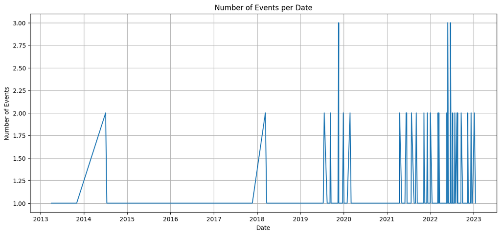

```python
events_per_date = df.groupby('Date').size().reset_index(name='count')


plt.figure(figsize=(14,6))
plt.plot(events_per_date['Date'], events_per_date['count'])
plt.title('Number of Events per Date')
plt.xlabel('Date')
plt.ylabel('Number of Events')
plt.grid(True)
plt.show()
```

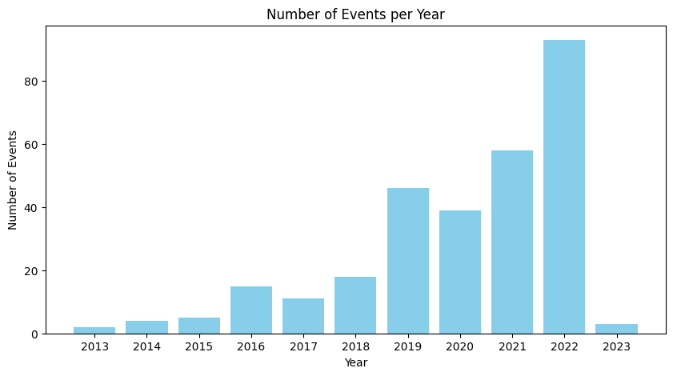

```python
# Events count per year
df['Year'] = df['Date'].dt.year
events_per_year = df.groupby('Year').size().reset_index(name='count')


plt.figure(figsize=(10,5))
plt.bar(events_per_year['Year'], events_per_year['count'], color='skyblue')
plt.title('Number of Events per Year')
plt.xlabel('Year')
plt.ylabel('Number of Events')
plt.xticks(events_per_year['Year'])
plt.show()
```

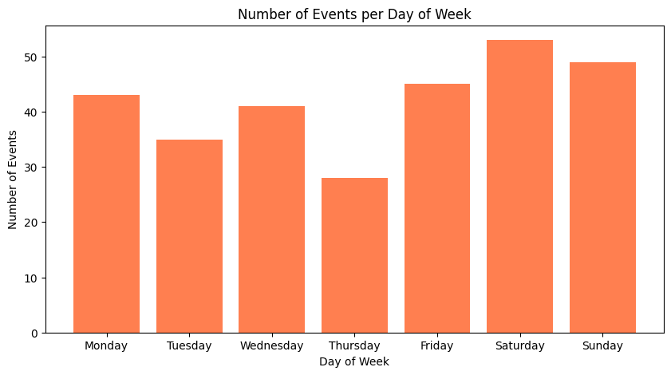

```python
#Events count per day of week
df['DayOfWeek'] = df['Date'].dt.day_name()
events_per_day = df.groupby('DayOfWeek').size().reindex([
    'Monday', 'Tuesday', 'Wednesday', 'Thursday', 'Friday', 'Saturday', 'Sunday'
]).reset_index(name='count')

plt.figure(figsize=(10,5))
plt.bar(events_per_day['DayOfWeek'], events_per_day['count'], color='coral')
plt.title('Number of Events per Day of Week')
plt.xlabel('Day of Week')
plt.ylabel('Number of Events')
plt.show()
```

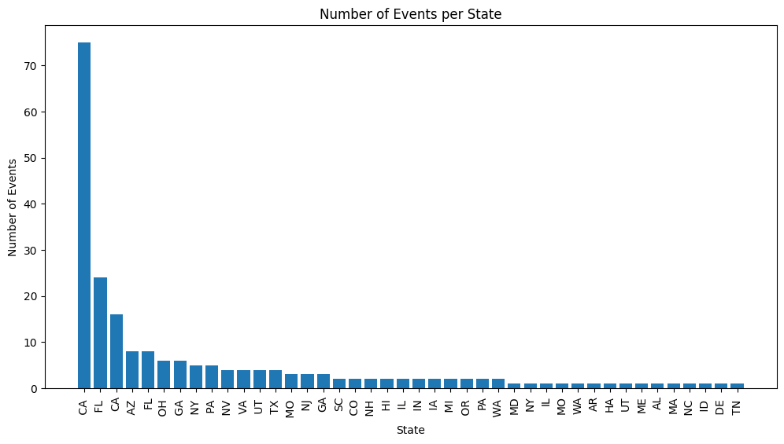

```python
#Events count per State
events_per_state = df['State'].value_counts().reset_index()
events_per_state.columns = ['State', 'count']

plt.figure(figsize=(12,6))
plt.bar(events_per_state['State'], events_per_state['count'])
plt.title('Number of Events per State')
plt.xlabel('State')
plt.ylabel('Number of Events')
plt.xticks(rotation=90)
plt.show()
```

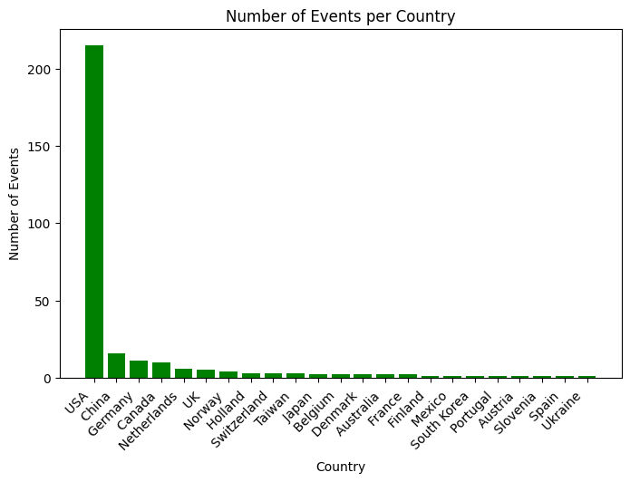

```python
#Events count per Country
events_per_country = df['Country'].value_counts().reset_index()
events_per_country.columns = ['Country', 'count']

plt.figure(figsize=(8,5))
plt.bar(events_per_country['Country'], events_per_country['count'], color='green')
plt.title('Number of Events per Country')
plt.xlabel('Country')
plt.ylabel('Number of Events')
plt.xticks(rotation=45, ha='right')
plt.show()
```

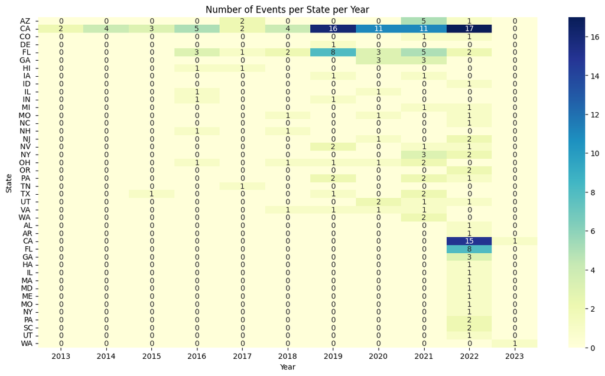

```python
#Heatmap of events per State and Year


state_year = df.groupby(['State', 'Year']).size().unstack(fill_value=0)

plt.figure(figsize=(15,8))
sns.heatmap(state_year, annot=True, fmt='d', cmap='YlGnBu')
plt.title('Number of Events per State per Year')
plt.xlabel('Year')
plt.ylabel('State')
plt.show()
```

**b.Analyze the different aspects of the death events. For example:**

- What is the number of victims (deaths) in each accident?

```python
# Show accident ID and deaths
if 'Case #' in df.columns:
    print(df[['Case #', 'Deaths']])
else:
    print(df[['Deaths']])
```

```
     Case #  Deaths
0     294.0     1.0
1     293.0     1.0
2     292.0     1.0
3     291.0     1.0
4     290.0     1.0
..      ...     ...
289     5.0     1.0
290     4.0     1.0
291     3.0     3.0
292     2.0     1.0
293     1.0     2.0

[294 rows x 2 columns]
```

```python
print("Deaths per accident statistics:")
print(df['Deaths'].describe())
df['Deaths'] = pd.to_numeric(df['Deaths'], errors='coerce')
# Count how many accidents with zero deaths vs non-zero deaths
print("\nAccidents with zero deaths:", (df['Deaths'] == 0).sum())
print("Accidents with one or more deaths:", (df['Deaths'] >=1).sum())
```

```
Deaths per accident statistics:
count    294.000000
mean       1.200680
std        0.513171
min        1.000000
25%        1.000000
50%        1.000000
75%        1.000000
max        4.000000
Name: Deaths, dtype: float64

Accidents with zero deaths: 0
Accidents with one or more deaths: 294
```

- How many times did tesla drivers die ?

```python
# Count number of deaths
tesla_driver_deaths = (df['Verified Tesla Autopilot Deaths'].dropna().astype(int) >= 1).sum()

print(f"Tesla drivers died in {tesla_driver_deaths} accident(s).")
```

[output not shown]

- What is the proportion of events in which one or more occupants died ?

```python
# Ensure 'Deaths' is numeric
df['Deaths'] = pd.to_numeric(df['Deaths'], errors='coerce')

# Total number of events
total_events = len(df)

# Events with at least one death
fatal_events = (df['Deaths'] >= 1).sum()

# Proportion calculation
proportion = fatal_events / total_events

print(f"Total Events: {total_events}")
print(f"Events with ≥1 Death: {fatal_events}")
print(f"Proportion: {proportion:.2%}")
```

```
Total Events: 294
Events with ≥1 Death: 294
Proportion: 100.00%
```

- What is the distribution of events in which the vehicle hit a cyclist or a pedestrian ?

```
Distribution of cyclist/pedestrian hits:
Cyclists/ Peds
1.0    42
2.0     2
Name: count, dtype: int64
```

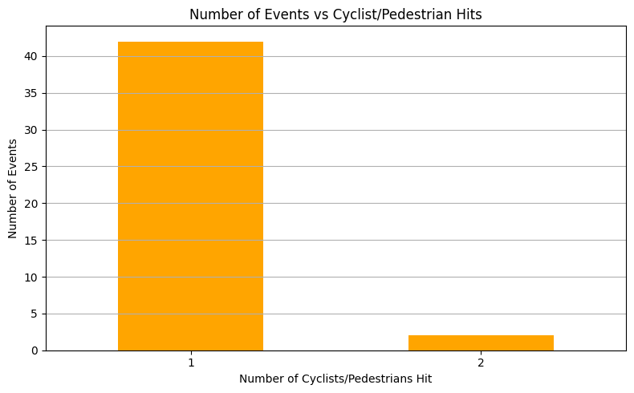

```python
df['Cyclists/ Peds'] = pd.to_numeric(df['Cyclists/ Peds'], errors='coerce')

print("Distribution of cyclist/pedestrian hits:")
print(df['Cyclists/ Peds'].value_counts().sort_index())



plt.figure(figsize=(8,5))
df['Cyclists/ Peds'].dropna().astype(int).value_counts().sort_index().plot(kind='bar', color='orange')
plt.title('Number of Events vs Cyclist/Pedestrian Hits')
plt.xlabel('Number of Cyclists/Pedestrians Hit')
plt.ylabel('Number of Events')
plt.xticks(rotation=0)
plt.grid(axis='y')
plt.tight_layout()
plt.show()
```

- How many times did the accident involve the death of an occupant or driver of a Tesla along with a cyclist or pedestrian?

```python
# Convert relevant columns
print(df.columns)
df['Cyclists/ Peds'] = pd.to_numeric(df['Cyclists/ Peds'], errors='coerce')
df['Tesla driver'] = pd.to_numeric(df['Tesla driver'], errors='coerce')
df['Tesla occupant'] = pd.to_numeric(df['Tesla occupant'], errors='coerce')

tesla_death = (
    (df['Tesla driver'] >= 1) |
    (df['Tesla occupant'] >= 1)
)
cycl_peds_hit = df['Cyclists/ Peds'] >= 1
combined_condition = tesla_death & cycl_peds_hit
count = combined_condition.sum()

print(f"Number of accidents involving Tesla driver/occupant death AND cyclist/pedestrian: {count}")
```

```
Index(['Case #', 'Year', 'Date', 'Country', 'State', 'Description', 'Deaths',
       'Tesla driver', 'Tesla occupant', 'Other vehicle', 'Cyclists/ Peds',
       'TSLA+cycl / peds', 'Model', 'Autopilot claimed',
       'Verified Tesla Autopilot Deaths',
       'Verified Tesla Autopilot Deaths + All Deaths Reported to NHTSA SGO',
       'Deceased 1', 'Deceased 2', 'Deceased 3', 'Deceased 4', 'DayOfWeek'],
      dtype='object')
Number of accidents involving Tesla driver/occupant death AND cyclist/pedestrian: 1
```

- What is the frequency of Tesla colliding with other vehicles ?

```
Frequency of Tesla colliding with other vehicles:
Other vehicle
1.0    95
2.0    11
3.0     3
4.0     1
Name: count, dtype: int64
```

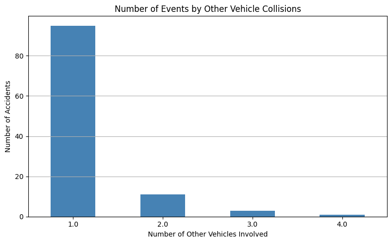

```python
df['Other vehicle'] = pd.to_numeric(df['Other vehicle'], errors='coerce')
print("Frequency of Tesla colliding with other vehicles:")
count_other_vehicles=df['Other vehicle'].value_counts().sort_index()
print(count_other_vehicles)



plt.figure(figsize=(8, 5))
count_other_vehicles[count_other_vehicles>=1].plot(kind='bar', color='steelblue')
plt.title('Number of Events by Other Vehicle Collisions')
plt.xlabel('Number of Other Vehicles Involved')
plt.ylabel('Number of Accidents')
plt.xticks(rotation=0)
plt.grid(axis='y')
plt.tight_layout()
plt.show()
```

**c. Study the event distribution across models**

```
Unique Tesla Models:
[nan 'Y' '1' '2' '3' 'S' 'X']
Event distribution by Tesla model:
Model
S    45
3    39
X    17
Y    10
1     1
2     1
Name: count, dtype: int64
```

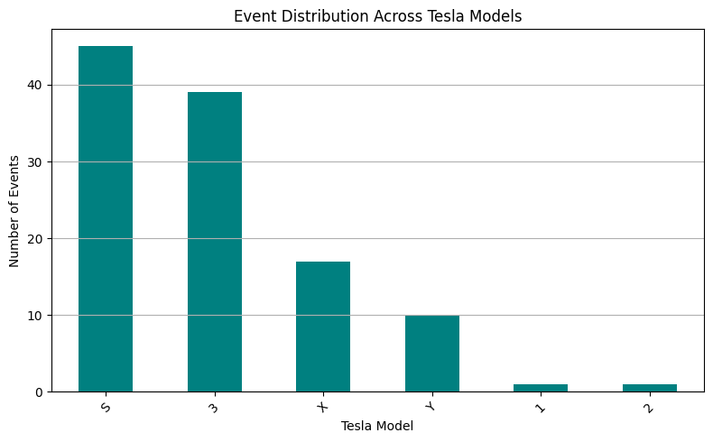

```
Percentage distribution by model:
Model
S    39.82
3    34.51
X    15.04
Y     8.85
1     0.88
2     0.88
Name: count, dtype: float64
Total deaths per Tesla model:
Model
S    53.0
3    47.0
X    19.0
Y    13.0
2     1.0
1     1.0
Name: Deaths, dtype: float64
```

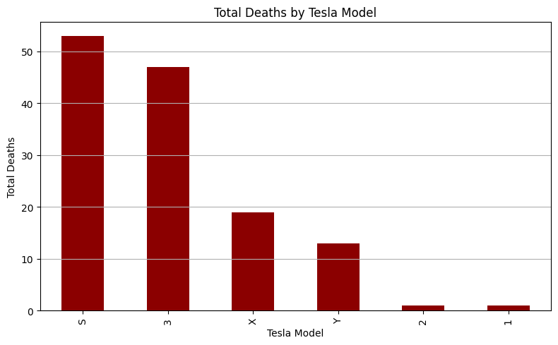

```
Autopilot claimed status by Tesla model:
Autopilot claimed   1  2
Model
3                  10  0
S                   5  2
X                   4  0
Y                   2  0
```

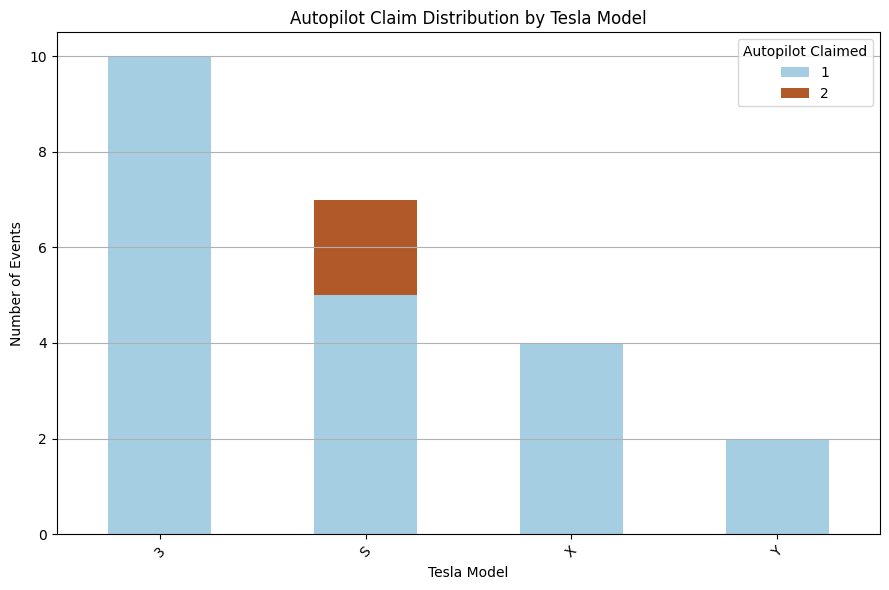

```
Cyclist/Pedestrian hits per Tesla model:
Model
3    6.0
S    5.0
X    5.0
Y    2.0
2    0.0
1    0.0
Name: Cyclists/ Peds, dtype: float64
```

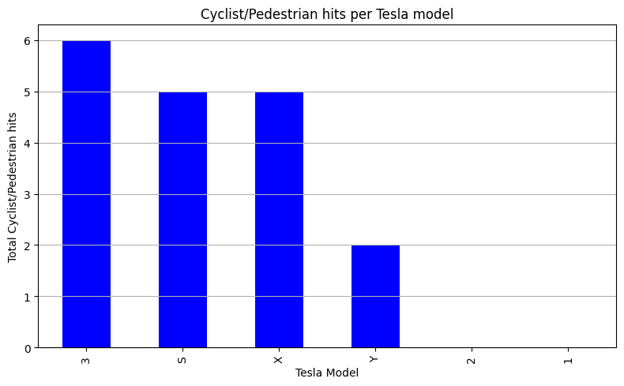

```python
# Standardize formatting
df['Model'] = df['Model'].str.strip().str.title()

# View unique models
print("Unique Tesla Models:")
print(df['Model'].unique())

model_counts = df['Model'].value_counts()

print("Event distribution by Tesla model:")
print(model_counts)



plt.figure(figsize=(8, 5))
model_counts.plot(kind='bar', color='teal')
plt.title('Event Distribution Across Tesla Models')
plt.xlabel('Tesla Model')
plt.ylabel('Number of Events')
plt.xticks(rotation=45)
plt.grid(axis='y')
plt.tight_layout()
plt.show()

model_percentage = model_counts / model_counts.sum() * 100
print("Percentage distribution by model:")
print(model_percentage.round(2))


# Ensure 'Deaths' is numeric
df['Deaths'] = pd.to_numeric(df['Deaths'], errors='coerce')

# Total deaths per model
deaths_per_model = df.groupby('Model')['Deaths'].sum().sort_values(ascending=False)

print("Total deaths per Tesla model:")
print(deaths_per_model)

deaths_per_model.plot(kind='bar', color='darkred', figsize=(8, 5))
plt.title('Total Deaths by Tesla Model')
plt.xlabel('Tesla Model')
plt.ylabel('Total Deaths')
plt.grid(axis='y')
plt.tight_layout()
plt.show()

df['Autopilot claimed'] = df['Autopilot claimed'].str.strip().str.title()

autopilot_claimed_model = df.groupby(['Model', 'Autopilot claimed']).size().unstack(fill_value=0)

print("Autopilot claimed status by Tesla model:")
print(autopilot_claimed_model)


autopilot_claimed_model.plot(kind='bar', stacked=True, figsize=(9, 6), colormap='Paired')
plt.title('Autopilot Claim Distribution by Tesla Model')
plt.xlabel('Tesla Model')
plt.ylabel('Number of Events')
plt.xticks(rotation=45)
plt.tight_layout()
plt.legend(title='Autopilot Claimed')
plt.grid(axis='y')
plt.show()

df['Cyclists/ Peds'] = pd.to_numeric(df['Cyclists/ Peds'], errors='coerce')
cycl_peds_per_model = df.groupby('Model')['Cyclists/ Peds'].sum().sort_values(ascending=False)

print("Cyclist/Pedestrian hits per Tesla model:")
print(cycl_peds_per_model)
cycl_peds_per_model.plot(kind='bar', color='blue', figsize=(8, 5))
plt.title('Cyclist/Pedestrian hits per Tesla model')
plt.xlabel('Tesla Model')
plt.ylabel('Total Cyclist/Pedestrian hits')
plt.grid(axis='y')
plt.tight_layout()
plt.show()
```

**d.Check the distribution of verified Tesla autopilot deaths**

```
Summary of Verified Tesla Autopilot Deaths:
count      23.000000
mean      186.652174
std       579.648295
min         1.000000
25%         1.000000
50%         1.000000
75%         9.500000
max      2022.000000
Name: Verified Tesla Autopilot Deaths, dtype: float64
Verified Tesla Autopilot Deaths
1.0       13
2.0        3
3.0        1
16.0       1
19.0       1
75.0       1
118.0      1
2021.0     1
2022.0     1
Name: count, dtype: int64
```

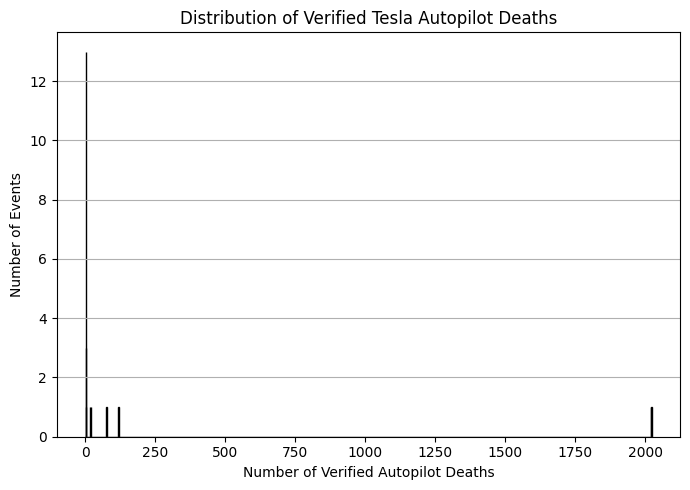

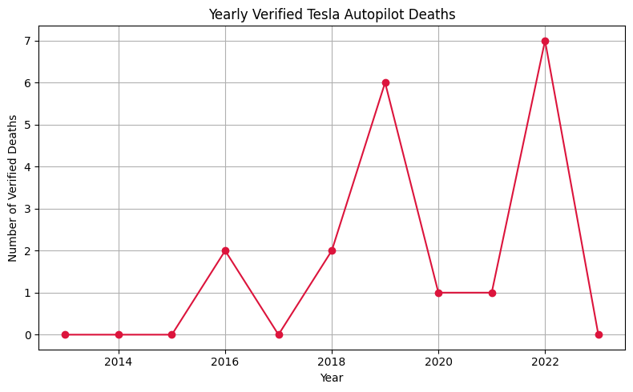

```python
# Ensure it's numeric
df['Verified Tesla Autopilot Deaths'] = pd.to_numeric(df['Verified Tesla Autopilot Deaths'], errors='coerce')
print("Summary of Verified Tesla Autopilot Deaths:")
print(df['Verified Tesla Autopilot Deaths'].describe())
# Count of how many events had 0, 1, 2,... verified deaths
print(df['Verified Tesla Autopilot Deaths'].value_counts().sort_index())


plt.figure(figsize=(7, 5))
df['Verified Tesla Autopilot Deaths'].dropna().astype(int).plot.hist(bins=range(0, int(df['Verified Tesla Autopilot Deaths'].max()) + 2), color='darkorange', edgecolor='black')
plt.title('Distribution of Verified Tesla Autopilot Deaths')
plt.xlabel('Number of Verified Autopilot Deaths')
plt.ylabel('Number of Events')
plt.grid(axis='y')
plt.tight_layout()
plt.show()
# Assuming 'Year' is available
df['Year'] = pd.to_numeric(df['Year'], errors='coerce')

autopilot_deaths_yearly = df.groupby('Year')['Verified Tesla Autopilot Deaths'].sum()

autopilot_deaths_yearly.plot(kind='line', marker='o', figsize=(8, 5), color='crimson')
plt.title('Yearly Verified Tesla Autopilot Deaths')
plt.xlabel('Year')
plt.ylabel('Number of Verified Deaths')
plt.grid(True)
plt.tight_layout()
plt.show()
```